# Kaggle Titanic Competition

## Intro

This is a Jupyter Notebook analysis on the Titanic competition from Kaggle. First of all I going to do a

### Exploratory Analysis

```python
import pandas as pd

df = pd.read_csv('./data/train.csv')
print(df.shape)
df.head()
```

```
(891, 12)
```

|  | PassengerId | Survived | Pclass | Name | Sex | Age | SibSp | Parch | Ticket | Fare | Cabin | Embarked |
| --- | --- | --- | --- | --- | --- | --- | --- | --- | --- | --- | --- | --- |
| 0 | 1 | 0 | 3 | Braund, Mr. Owen Harris | male | 22.0 | 1 | 0 | A/5 21171 | 7.2500 | NaN | S |
| 1 | 2 | 1 | 1 | Cumings, Mrs. John Bradley (Florence Briggs Th... | female | 38.0 | 1 | 0 | PC 17599 | 71.2833 | C85 | C |
| 2 | 3 | 1 | 3 | Heikkinen, Miss. Laina | female | 26.0 | 0 | 0 | STON/O2. 3101282 | 7.9250 | NaN | S |
| 3 | 4 | 1 | 1 | Futrelle, Mrs. Jacques Heath (Lily May Peel) | female | 35.0 | 1 | 0 | 113803 | 53.1000 | C123 | S |
| 4 | 5 | 0 | 3 | Allen, Mr. William Henry | male | 35.0 | 0 | 0 | 373450 | 8.0500 | NaN | S |

As we can see, we have 12 columns for 891 observations. 11 of this columns as features and the 'Survived' one as our target.

```python
print(df[['Name', 'Sex', 'Ticket', 'Cabin', 'Embarked']].count())
df.describe()
```

```
Name        891
Sex         891
Ticket      891
Cabin       204
Embarked    889
dtype: int64
```

|  | PassengerId | Survived | Pclass | Age | SibSp | Parch | Fare |
| --- | --- | --- | --- | --- | --- | --- | --- |
| count | 891.000000 | 891.000000 | 891.000000 | 714.000000 | 891.000000 | 891.000000 | 891.000000 |
| mean | 446.000000 | 0.383838 | 2.308642 | 29.699118 | 0.523008 | 0.381594 | 32.204208 |
| std | 257.353842 | 0.486592 | 0.836071 | 14.526497 | 1.102743 | 0.806057 | 49.693429 |
| min | 1.000000 | 0.000000 | 1.000000 | 0.420000 | 0.000000 | 0.000000 | 0.000000 |
| 25% | 223.500000 | 0.000000 | 2.000000 | 20.125000 | 0.000000 | 0.000000 | 7.910400 |
| 50% | 446.000000 | 0.000000 | 3.000000 | 28.000000 | 0.000000 | 0.000000 | 14.454200 |
| 75% | 668.500000 | 1.000000 | 3.000000 | 38.000000 | 1.000000 | 0.000000 | 31.000000 |
| max | 891.000000 | 1.000000 | 3.000000 | 80.000000 | 8.000000 | 6.000000 | 512.329200 |

Most of the values from 'Cabin' are missing. So I'm going to drop this column. Also, I'm going to drop the 'PassengerId' as well, once it brings no valuble info about the observations.

```python
df = df.drop(['PassengerId', 'Cabin'], axis=1)
print(df.shape)
df.head()
```

```
(891, 10)
```

|  | Survived | Pclass | Name | Sex | Age | SibSp | Parch | Ticket | Fare | Embarked |
| --- | --- | --- | --- | --- | --- | --- | --- | --- | --- | --- |
| 0 | 0 | 3 | Braund, Mr. Owen Harris | male | 22.0 | 1 | 0 | A/5 21171 | 7.2500 | S |
| 1 | 1 | 1 | Cumings, Mrs. John Bradley (Florence Briggs Th... | female | 38.0 | 1 | 0 | PC 17599 | 71.2833 | C |
| 2 | 1 | 3 | Heikkinen, Miss. Laina | female | 26.0 | 0 | 0 | STON/O2. 3101282 | 7.9250 | S |
| 3 | 1 | 1 | Futrelle, Mrs. Jacques Heath (Lily May Peel) | female | 35.0 | 1 | 0 | 113803 | 53.1000 | S |
| 4 | 0 | 3 | Allen, Mr. William Henry | male | 35.0 | 0 | 0 | 373450 | 8.0500 | S |

Once 'Sex' and 'Embarked' are categorical, lets convert it to numeric so it become easier to work with.

```python
print(df['Sex'].unique())
print(df['Embarked'].unique())
```

```
['male' 'female']
['S' 'C' 'Q' nan]
```

```python
df['Sex'] = df['Sex'].replace(['male', 'female'], [1, 2])
df['Embarked'] = df['Embarked'].replace(['S', 'C', 'Q'], [1, 2, 3])
df.head()
```

|  | Survived | Pclass | Name | Sex | Age | SibSp | Parch | Ticket | Fare | Embarked |
| --- | --- | --- | --- | --- | --- | --- | --- | --- | --- | --- |
| 0 | 0 | 3 | Braund, Mr. Owen Harris | 1 | 22.0 | 1 | 0 | A/5 21171 | 7.2500 | 1.0 |
| 1 | 1 | 1 | Cumings, Mrs. John Bradley (Florence Briggs Th... | 2 | 38.0 | 1 | 0 | PC 17599 | 71.2833 | 2.0 |
| 2 | 1 | 3 | Heikkinen, Miss. Laina | 2 | 26.0 | 0 | 0 | STON/O2. 3101282 | 7.9250 | 1.0 |
| 3 | 1 | 1 | Futrelle, Mrs. Jacques Heath (Lily May Peel) | 2 | 35.0 | 1 | 0 | 113803 | 53.1000 | 1.0 |
| 4 | 0 | 3 | Allen, Mr. William Henry | 1 | 35.0 | 0 | 0 | 373450 | 8.0500 | 1.0 |

Now let's take a look at the correlations...

```python
df.corr()
```

|  | Survived | Pclass | Sex | Age | SibSp | Parch | Fare | Embarked |
| --- | --- | --- | --- | --- | --- | --- | --- | --- |
| Survived | 1.000000 | -0.338481 | 0.543351 | -0.077221 | -0.035322 | 0.081629 | 0.257307 | 0.108669 |
| Pclass | -0.338481 | 1.000000 | -0.131900 | -0.369226 | 0.083081 | 0.018443 | -0.549500 | 0.043835 |
| Sex | 0.543351 | -0.131900 | 1.000000 | -0.093254 | 0.114631 | 0.245489 | 0.182333 | 0.118593 |
| Age | -0.077221 | -0.369226 | -0.093254 | 1.000000 | -0.308247 | -0.189119 | 0.096067 | 0.012186 |
| SibSp | -0.035322 | 0.083081 | 0.114631 | -0.308247 | 1.000000 | 0.414838 | 0.159651 | -0.060606 |
| Parch | 0.081629 | 0.018443 | 0.245489 | -0.189119 | 0.414838 | 1.000000 | 0.216225 | -0.079320 |
| Fare | 0.257307 | -0.549500 | 0.182333 | 0.096067 | 0.159651 | 0.216225 | 1.000000 | 0.063462 |
| Embarked | 0.108669 | 0.043835 | 0.118593 | 0.012186 | -0.060606 | -0.079320 | 0.063462 | 1.000000 |

'Sex' has a very good correlation with our target. Lets take a deeper look.

```
There are 577 males and 314 females from a total of 891.
        Survived  Deceased
Sex
Female       233        81
Male         109       468
```

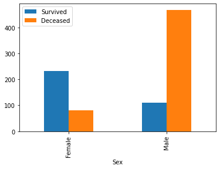

```python
male_count = df[df['Sex'] == 1]['Name'].count()
female_count = df[df['Sex'] == 2]['Name'].count()
total = df.shape[0]

print('There are {} males and {} females from a total of {}.'.format(male_count, female_count, total))

df_sex = df[['Sex', 'Survived']].copy()
df_sex['Sex'] = df_sex['Sex'].apply(lambda s: 'Male' if s == 1 else 'Female')
df_sex['Deceased'] = (df_sex['Survived'] - 1) * -1
df_sex = df_sex.groupby('Sex').sum()
print(df_sex)
df_sex.plot(kind='bar')
```

Although most of people on board were male (64.75%), only 18.89% of them survived. On the contrary, 74.20% of females on board survived, even though they were only 35.24% of the total.

It is clear this is a very important feature on this problem.

The second feature with strongest correlation was 'Pclass'.

```
        Survived  Deceased
Pclass
1            136        80
2             87        97
3            119       372
```

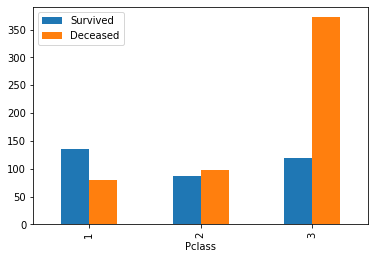

```python
df_class = df[['Pclass', 'Survived']].copy()
df_class['Deceased'] = (df_class['Survived'] - 1) * -1
df_class = df_class.groupby('Pclass').sum()
print(df_class)
df_class.plot(kind='bar')
```

It is clear that being on 'Pclass' 3 can be very deadly.

The next feature with strongest correlation is 'Fare'. And it is closely related to the 'Pclass' feature. This makes sense: the more you pay for your ticket, better your class will be.

## Feature Selection

First of all, lets take care of ours NaN values.

```python
df['Age'] = df['Age'].fillna(df['Age'].mean())
df = df.dropna()
print(df.shape)
```

```
(889, 10)
```

Second, let's split our features from our target.

```python
X = df.drop('Survived', axis=1)
y = df['Survived']

X.head()
```

|  | Pclass | Name | Sex | Age | SibSp | Parch | Ticket | Fare | Embarked |
| --- | --- | --- | --- | --- | --- | --- | --- | --- | --- |
| 0 | 3 | Braund, Mr. Owen Harris | 1 | 22.0 | 1 | 0 | A/5 21171 | 7.2500 | 1.0 |
| 1 | 1 | Cumings, Mrs. John Bradley (Florence Briggs Th... | 2 | 38.0 | 1 | 0 | PC 17599 | 71.2833 | 2.0 |
| 2 | 3 | Heikkinen, Miss. Laina | 2 | 26.0 | 0 | 0 | STON/O2. 3101282 | 7.9250 | 1.0 |
| 3 | 1 | Futrelle, Mrs. Jacques Heath (Lily May Peel) | 2 | 35.0 | 1 | 0 | 113803 | 53.1000 | 1.0 |
| 4 | 3 | Allen, Mr. William Henry | 1 | 35.0 | 0 | 0 | 373450 | 8.0500 | 1.0 |

So we have three very promissing features. Two features ('Name' and 'Ticket') that don't bring much usefull info without any refactor. And the others doesn't seam to have much value to this problem.

That said, first I'm going to drop 'Name' and 'Ticket'.

```python
X = X.drop(['Name', 'Ticket'], axis=1)
print(X.shape)
X.head()
```

```
(889, 7)
```

|  | Pclass | Sex | Age | SibSp | Parch | Fare | Embarked |
| --- | --- | --- | --- | --- | --- | --- | --- |
| 0 | 3 | 1 | 22.0 | 1 | 0 | 7.2500 | 1.0 |
| 1 | 1 | 2 | 38.0 | 1 | 0 | 71.2833 | 2.0 |
| 2 | 3 | 2 | 26.0 | 0 | 0 | 7.9250 | 1.0 |
| 3 | 1 | 2 | 35.0 | 1 | 0 | 53.1000 | 1.0 |
| 4 | 3 | 1 | 35.0 | 0 | 0 | 8.0500 | 1.0 |

## Benchmark

Now I'm going to use all of this dataframe as benchmark. To do so, let's train a model using a simple Decision Tree Classifier.

```python
from sklearn.model_selection import train_test_split
from sklearn.tree import DecisionTreeClassifier

X_train, X_test, y_train, y_test = train_test_split(X, y, test_size=.3, random_state=42)

model = DecisionTreeClassifier()
model.fit(X_train, y_train)
```

```
DecisionTreeClassifier()
```

Then we check on the performance of the model.

```python
from sklearn.metrics import accuracy_score, confusion_matrix, classification_report

def print_performance(y_test, y_predict):
    print(accuracy_score(y_test, y_predict))
    print(confusion_matrix(y_test, y_predict))
    print(classification_report(y_test, y_predict))
```

```python
y_predict = model.predict(X_test)

print_performance(y_test, y_predict)
```

```
0.7565543071161048
[[131  36]
 [ 29  71]]
              precision    recall  f1-score   support

           0       0.82      0.78      0.80       167
           1       0.66      0.71      0.69       100

    accuracy                           0.76       267
   macro avg       0.74      0.75      0.74       267
weighted avg       0.76      0.76      0.76       267
```

Now I'm going to try improving the performance by excluding the features with low correlation value.

```python
X.head()
```

|  | Pclass | Sex | Age | SibSp | Parch | Fare | Embarked |
| --- | --- | --- | --- | --- | --- | --- | --- |
| 0 | 3 | 1 | 22.0 | 1 | 0 | 7.2500 | 1.0 |
| 1 | 1 | 2 | 38.0 | 1 | 0 | 71.2833 | 2.0 |
| 2 | 3 | 2 | 26.0 | 0 | 0 | 7.9250 | 1.0 |
| 3 | 1 | 2 | 35.0 | 1 | 0 | 53.1000 | 1.0 |
| 4 | 3 | 1 | 35.0 | 0 | 0 | 8.0500 | 1.0 |

```python
X = X.drop(['Age', 'SibSp', 'Parch'], axis=1)
X.head()
```

|  | Pclass | Sex | Fare | Embarked |
| --- | --- | --- | --- | --- |
| 0 | 3 | 1 | 7.2500 | 1.0 |
| 1 | 1 | 2 | 71.2833 | 2.0 |
| 2 | 3 | 2 | 7.9250 | 1.0 |
| 3 | 1 | 2 | 53.1000 | 1.0 |
| 4 | 3 | 1 | 8.0500 | 1.0 |

```python
X_train, X_test, y_train, y_test = train_test_split(X, y, test_size=.3, random_state=42)

model = DecisionTreeClassifier()
model.fit(X_train, y_train)

y_predict = model.predict(X_test)

print_performance(y_test, y_predict)
```

```
0.8089887640449438
[[148  19]
 [ 32  68]]
              precision    recall  f1-score   support

           0       0.82      0.89      0.85       167
           1       0.78      0.68      0.73       100

    accuracy                           0.81       267
   macro avg       0.80      0.78      0.79       267
weighted avg       0.81      0.81      0.81       267
```

In fact we had a important improvement on performance with this feature selection.

## Model Training

Now lets try to improve even further using a ensemble model alied with a grid search strategy for param tunning.

```python
from sklearn.ensemble import RandomForestClassifier

model = RandomForestClassifier()
print(model.get_params())
```

```
{'bootstrap': True, 'ccp_alpha': 0.0, 'class_weight': None, 'criterion': 'gini', 'max_depth': None, 'max_features': 'auto', 'max_leaf_nodes': None, 'max_samples': None, 'min_impurity_decrease': 0.0, 'min_samples_leaf': 1, 'min_samples_split': 2, 'min_weight_fraction_leaf': 0.0, 'n_estimators': 100, …
```

Lets use a Randomized cross validation strategy to find a better solution.

```python
from sklearn.model_selection import RandomizedSearchCV

params = {
    'n_estimators': [20, 50, 100, 150, 200, 300],
    'criterion': ['gini', 'entropy'],
    'max_features': ['sqrt', 'log2', None, 3]
}

grids = RandomizedSearchCV(model, params, n_iter=20, cv=5, n_jobs=-1, random_state=42)
grids.fit(X_train, y_train)

params = grids.best_params_
print(params)
```

```
{'n_estimators': 150, 'max_features': None, 'criterion': 'gini'}
```

Train the model using the best params found.

```python
model = RandomForestClassifier()
model.set_params(**params)
model.fit(X_train, y_train)

y_predict = model.predict(X_test)

print_performance(y_test, y_predict)
```

```
0.8052434456928839
[[147  20]
 [ 32  68]]
              precision    recall  f1-score   support

           0       0.82      0.88      0.85       167
           1       0.77      0.68      0.72       100

    accuracy                           0.81       267
   macro avg       0.80      0.78      0.79       267
weighted avg       0.80      0.81      0.80       267
```

## Generating Result

Now that we have a trained model, lets generate the result CSV file.

First lets create a function to clean our dataset.

```python
def data_eng(df:pd.DataFrame):
    new_df = df
    new_df = new_df.drop(['PassengerId', 'Name', 'Age', 'SibSp', 'Parch', 'Ticket', 'Cabin'], axis=1)
    new_df['Sex'] = new_df['Sex'].replace(['male', 'female'], [1, 2])
    new_df['Embarked'] = new_df['Embarked'].replace(['S', 'C', 'Q'], [1, 2, 3])
    new_df['Fare'] = new_df['Fare'].fillna(new_df['Fare'].mean())
    return new_df
```

Now lets read our 'test' dataset and cleanup our observations.

```python
df_result = pd.read_csv('./data/test.csv')

X_result = data_eng(df_result)
X_result.head()
```

|  | Pclass | Sex | Fare | Embarked |
| --- | --- | --- | --- | --- |
| 0 | 3 | 1 | 7.8292 | 3 |
| 1 | 3 | 2 | 7.0000 | 1 |
| 2 | 2 | 1 | 9.6875 | 3 |
| 3 | 3 | 1 | 8.6625 | 1 |
| 4 | 3 | 2 | 12.2875 | 1 |

Use the trained model to predict final results and write it to 'result.csv'.

```python
y_result = model.predict(X_result)

result = pd.DataFrame()
result['PassengerId'] = df_result['PassengerId']
result['Survived'] = pd.Series(y_result)
result.to_csv('result.csv', index=False)

result.head()
```

|  | PassengerId | Survived |
| --- | --- | --- |
| 0 | 892 | 0 |
| 1 | 893 | 1 |
| 2 | 894 | 0 |
| 3 | 895 | 0 |
| 4 | 896 | 1 |

This file reached 0.78947 points on Kaggle competition.